# CASE STUDY - TERM DEPOSIT SUBSCRIPTION Submitted by Krishna Josyula

# Goal

Using the data collected from existing customers, build a model that will help the marketing team identify potential customers who are relatively more likely to subscribe term deposit and thus increase their hit ratio.

# Import all necessary modules and load the data

```python
import warnings
```

```python
pip install pandas-profiling --user
```

```python
pip install yellowbrick --user
```

```python
import numpy as np
import pandas as pd
from scipy import stats
import matplotlib.pyplot as plt
import seaborn as sns
```

```python
from sklearn.model_selection import train_test_split
from sklearn.tree import DecisionTreeClassifier
from sklearn.metrics import accuracy_score, f1_score, recall_score, precision_score, confusion_matrix

import statsmodels.api as sm

from scipy import stats

from sklearn import metrics
from sklearn.linear_model import LogisticRegression
from sklearn.metrics import classification_report,confusion_matrix
from sklearn.metrics import accuracy_score # Performance measure – Accuracy

from sklearn import preprocessing
from yellowbrick.classifier import ClassificationReport, ROCAUC

plt.style.use('ggplot')
pd.options.display.float_format = '{:,.2f}'.format
from IPython.core.display import display, HTML
display(HTML("<style>.container { width:95% !important; }</style>"))
```

```python
dfterm = pd.read_csv('bank-full.csv')
```

```python
dfterm.head()
```

|  | age | job | marital | education | default | balance | housing | loan | contact | day | month | duration | campaign | pdays | previous | poutcome | Target |
| --- | --- | --- | --- | --- | --- | --- | --- | --- | --- | --- | --- | --- | --- | --- | --- | --- | --- |
| 0 | 58 | management | married | tertiary | no | 2143 | yes | no | unknown | 5 | may | 261 | 1 | -1 | 0 | unknown | no |
| 1 | 44 | technician | single | secondary | no | 29 | yes | no | unknown | 5 | may | 151 | 1 | -1 | 0 | unknown | no |
| 2 | 33 | entrepreneur | married | secondary | no | 2 | yes | yes | unknown | 5 | may | 76 | 1 | -1 | 0 | unknown | no |
| 3 | 47 | blue-collar | married | unknown | no | 1506 | yes | no | unknown | 5 | may | 92 | 1 | -1 | 0 | unknown | no |
| 4 | 33 | unknown | single | unknown | no | 1 | no | no | unknown | 5 | may | 198 | 1 | -1 | 0 | unknown | no |

```python
dfterm.shape
```

```
(45211, 17)
```

# Deliverable -1

## 1. Univariate Analysis

### 1a. Univariate Analysis Data Types, Description of Univariate analysis – data types and description of the independent attributes which should include (name, meaning, range of values observed, central values (mean and median), standard deviation and quartiles, analysis of the body of distributions / tails, missing values, outliers.

### Key observations of the overall data and dataframe

### i. The data file comprises 45211 rows and 17 columns

```python
dfterm.dtypes
```

```
age           int64
job          object
marital      object
education    object
default      object
balance       int64
housing      object
loan         object
contact      object
day           int64
month        object
duration      int64
campaign      int64
pdays         int64
previous      int64
poutcome     object
Target       object
dtype: object
```

```python
dfterm.info()
```

```
<class 'pandas.core.frame.DataFrame'>
RangeIndex: 45211 entries, 0 to 45210
Data columns (total 17 columns):
 #   Column     Non-Null Count  Dtype
---  ------     --------------  -----
 0   age        45211 non-null  int64
 1   job        45211 non-null  object
 2   marital    45211 non-null  object
 3   education  45211 non-null  object
 4   default    45211 non-null  object
 5   balance    45211 non-null  int64
 6   housing    45211 non-null  object
 7   loan       45211 non-null  object
 8   contact    45211 non-null  object
 9   day        45211 non-null  int64
 10  month      45211 non-null  object
 11  duration   45211 non-null  int64
 12  campaign   45211 non-null  int64
 13  pdays      45211 non-null  int64
 14  previous   45211 non-null  int64
 15  poutcome   45211 non-null  object
 16  Target     45211 non-null  object
dtypes: int64(7), object(10)
memory usage: 5.9+ MB
```

### ii. Of the 17 columns 7 are are of Interger type and 10 are object type.

```python
#Let's check if there are ane any rows in the given data set with null values
dfterm.isnull().sum()
```

```
age          0
job          0
marital      0
education    0
default      0
balance      0
housing      0
loan         0
contact      0
day          0
month        0
duration     0
campaign     0
pdays        0
previous     0
poutcome     0
Target       0
dtype: int64
```

### iii. None of the columns has any null or missing value.

### iV. Number of unique values in each column:

```python
dfterm.nunique()
```

```
age            77
job            12
marital         3
education       4
default         2
balance      7168
housing         2
loan            2
contact         3
day            31
month          12
duration     1573
campaign       48
pdays         559
previous       41
poutcome        4
Target          2
dtype: int64
```

#### We now have a list of the number o unique values in each of the columns. In some columns we would expect binary or yes / no values like in default, housing, loan, poutcome and Target. But we can see in poutcome we have four values. We would need to investigate this during further analysis.

### v) Below we are finding out the distinct value counts for categorical columns - Categorical columns being Job, Marital, Education, Default, Housing, Loan, Contact, Month, Poutcome, Target, and for integer columns - Integer columns being Age, Balance, Day, Duration, Campaign, Pdays and Previous.

```python
list=['job','marital','education','default','housing','loan', 'contact','month','poutcome','Target']
for i in list:
    x = dfterm[i].value_counts()
    print("Column name is:",i,"and it's count is:" ,x)
    print()
```

```
Column name is: job and it's count is: blue-collar      9732
management       9458
technician       7597
admin.           5171
services         4154
retired          2264
self-employed    1579
entrepreneur     1487
unemployed       1303
housemaid        1240
student           938
unknown           288
Name: job, dtype: int64

Column name is: marital and it's count is: married     27214
single      12790
divorced     5207
Name: marital, dtype: int64

Column name is: education and it's count is: secondary    23202
tertiary     13301
primary       6851
unknown       1857
Name: education, dtype: int64

Column name is: default and it's count is: no     44396
yes      815
Name: default, dtype: int64

Column name is: housing and it's count is: yes    25130
no     20081
Name: housing, dtype: int64

Column name is: loan and it's count is: no     37967
yes     7244
Name: loan, dtype: int64

Column name is: contact and it's count is: cellular     29285
unknown      13020
telephone     2906
```

[output cut: 10 more lines]

```
oct      738
sep      579
mar      477
dec      214
Name: month, dtype: int64

Column name is: poutcome and it's count is: unknown    36959
failure     4901
other       1840
success     1511
Name: poutcome, dtype: int64

Column name is: Target and it's count is: no     39922
yes     5289
Name: Target, dtype: int64
```

### vi) Description of Independent Attributes

#### Bank client data:

##### 1 - age: (numeric)

##### 2 - job: type of job (categorical: 'admin.','blue-collar','entrepreneur','housemaid','management','retired','self-employed','services','student','technician','unemployed','unknown')

##### 3 - marital: marital status (categorical: 'divorced','married','single','unknown'; note: 'divorced' means divorced or widowed)

##### 4 - education: (categorical: primary, secondary, tertiary and unknown)

##### 5 - default: has credit in default? (categorical: 'no','yes','unknown')

##### 6 - housing: has housing loan? (categorical: 'no','yes','unknown')

##### 7 - loan: has personal loan? (categorical: 'no','yes','unknown')

##### 8 - balance: Balance of the individual.

#### Data Related to the last contact of the current campaign:

##### 12 - duration: last contact duration, in seconds (numeric). Important note: this attribute highly affects the output target (e.g., if duration=0 then y='no'). Yet, the duration is not known before a call is performed. Also, after the end of the call y is obviously known. Thus, this input should only be included for benchmark purposes and should be discarded if the intention is to have a realistic predictive model.

#### Other independent attributes:

##### 15 - previous: number of contacts performed before this campaign and for this client (numeric)

##### 16 - poutcome: outcome of the previous marketing campaign (categorical: 'unknown', 'failure','other','success')

```python
dfterm.describe().transpose()
```

|  | count | mean | std | min | 25% | 50% | 75% | max |
| --- | --- | --- | --- | --- | --- | --- | --- | --- |
| age | 45,211.00 | 40.94 | 10.62 | 18.00 | 33.00 | 39.00 | 48.00 | 95.00 |
| balance | 45,211.00 | 1,362.27 | 3,044.77 | -8,019.00 | 72.00 | 448.00 | 1,428.00 | 102,127.00 |
| day | 45,211.00 | 15.81 | 8.32 | 1.00 | 8.00 | 16.00 | 21.00 | 31.00 |
| duration | 45,211.00 | 258.16 | 257.53 | 0.00 | 103.00 | 180.00 | 319.00 | 4,918.00 |
| campaign | 45,211.00 | 2.76 | 3.10 | 1.00 | 1.00 | 2.00 | 3.00 | 63.00 |
| pdays | 45,211.00 | 40.20 | 100.13 | -1.00 | -1.00 | -1.00 | -1.00 | 871.00 |
| previous | 45,211.00 | 0.58 | 2.30 | 0.00 | 0.00 | 0.00 | 0.00 | 275.00 |

### vii) Observations based on describe of the dataframe:

##### 1. Age - Mean is 40.9 years and Median is 39 which are close so Age is normally distributed. Most of the people are young since 33 to 48 years old fall within the 25th to 75th percentiles.

##### - Considering normal distribution of age attribute the max of 95 years is an outlier as it is more than 75% + 1.75 times IQR. From Std Dev point 95 is 5.28 SD from median so 95 years is an outlier.

##### 2. Balance - Mean is 1362 while median is 448 therefore 'Balance' is right skewed distribution with fewer people having higher balance

##### - Max balance of 102127 clearly an outlier. Thus 'balance' data may have many more outliers

##### - Min balance is a negative number.

##### - The distribution of balance data has a huge standard deviation, 3044.76, relative to the mean, suggesting large variabilities in customers' balance levels

##### 3. Day - Mean is 15.8 which is very close to the nedian of 16 days hence 'Day' normal dikstriibution. Max and Min are within 3 SD so no outiier for Day attribute

##### 4. Duration - Mean of 258 is more than median of 180 therefore the distribution is right skewed. While the Min. being 0 id The Max is 4918 which is an outlier as it is more than 1.75 IQR of 75% and also is more than 10 times the SD of 257.5 days

##### 5. Campaign's data has 2.76 as mean and 2 as median, so this distribution too is right skewed. In this distribution too the max is outlier.

### viii) Using univariate analysis check the individual attributes for their basic statistic such as central values, spread, tails etc.

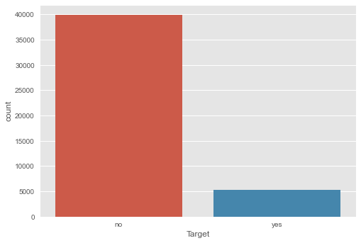

```python
sns.countplot(dfterm['Target'])
```

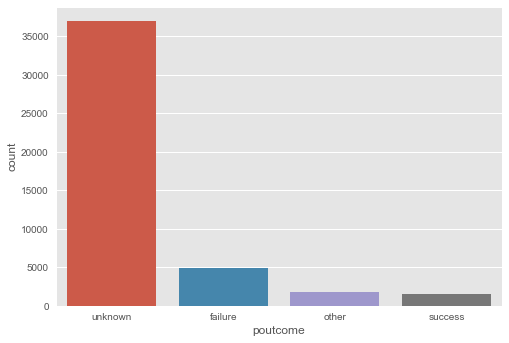

```python
sns.countplot(dfterm['poutcome'])
```

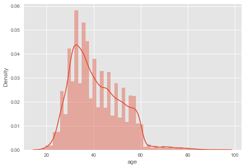

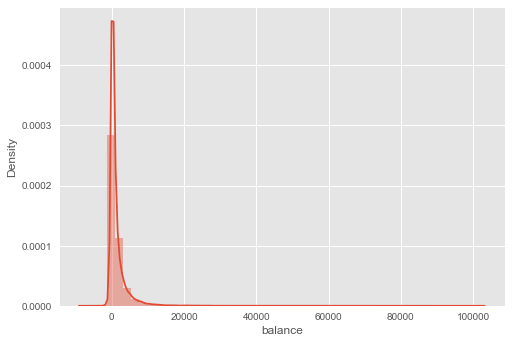

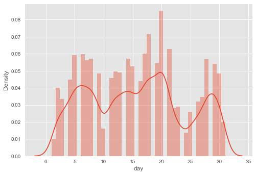

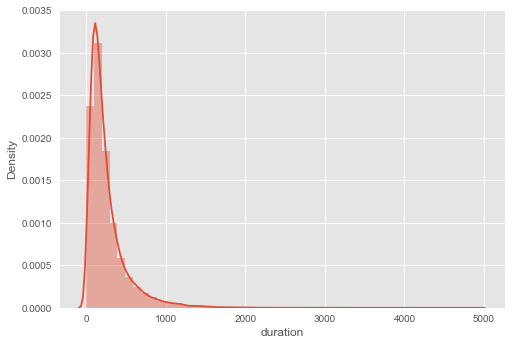

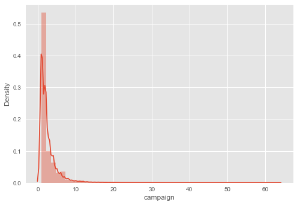

```python
#distplot for continuous columns:
for i in ['age','balance','day','duration','campaign']:
    sns.distplot(dfterm[i])
    plt.show()
```

##### From above charts we can say that Day and Age have less skewness compares to balance, duration and campaign which are highly skewed.

```python
#SKEWNESS - Besides checking visually we will determine the level of skewensss to confirm our previous observation about skewness of attributes which are integer types.

from scipy.stats import zscore
import scipy.stats as stats

#Let's check Skew in all numercial attributes


Skewness = pd.DataFrame({'Skewness' : [stats.skew(dfterm.age),stats.skew(dfterm.day),stats.skew(dfterm.balance),stats.skew(dfterm.duration),stats.skew(dfterm.campaign),stats.skew(dfterm.pdays),stats.skew(dfterm.previous) ]},
                        index=['age','day','balance', 'duration', 'campaign', 'pdays', 'previous'])  # Measure the skeweness of the required columns
Skewness
```

|  | Skewness |
| --- | --- |
| age | 0.68 |
| day | 0.09 |
| balance | 8.36 |
| duration | 3.14 |
| campaign | 4.90 |
| pdays | 2.62 |
| previous | 41.85 |

##### From above we can say that age and day atttributes do not have much skewness

##### But the attributes balance , duration, campaign, pdays, previous are highly skewed and also have lot of outliers

### vii) Missing values

##### From Description statistics of the dataframe we can conclude that there are no missing values. But there are values like “unknown”, “others”, which are not adding any value to the model and thus, these ambiguous values would have to br removed from the dataset.

### viii) Unknown and 'Other' Data

#### As was seen from count of various categorical columns:

##### 1. job attribue has 288 rows with value 'unknown'.

##### 2. Contact has 13020 rows which have value as 'unknown'.

##### 3, Attribute poutcome has 36959 'unknown' and 1840 'others' values

### 1b.Strategies to address the different data challenges such as data pollution, outlier’s treatment and missing values treatment.

#### As discussed earlier there are no missing values in the dataframe.

#### The data has data pollution and outliers which we have addressed below. We have first identified and removed those rows which have data like 'other'. Then from columns, where per EDA we had identified have outliers, we deleted the rows which have outlier data.

#### Data Pollution

##### As mentioned in section viii) of 1a for Unknown and Other data. To reduce data poluution we can remove the rows which have others in 'poutcome' column.

```python
dfterm1=dfterm
```

```python
dfterm1[dfterm1['poutcome']=='other']
```

|  | age | job | marital | education | default | balance | housing | loan | contact | day | month | duration | campaign | pdays | previous | poutcome | Target |
| --- | --- | --- | --- | --- | --- | --- | --- | --- | --- | --- | --- | --- | --- | --- | --- | --- | --- |
| 24062 | 42 | admin. | single | secondary | no | -247 | yes | yes | telephone | 21 | oct | 519 | 1 | 166 | 1 | other | yes |
| 24072 | 36 | management | married | tertiary | no | 2415 | yes | no | telephone | 22 | oct | 73 | 1 | 86 | 4 | other | no |
| 24086 | 44 | blue-collar | married | secondary | no | 1324 | yes | no | telephone | 25 | oct | 119 | 1 | 89 | 2 | other | no |
| 24122 | 26 | technician | single | tertiary | no | 172 | no | yes | telephone | 4 | nov | 21 | 1 | 140 | 4 | other | no |
| 24136 | 34 | management | married | tertiary | no | 1770 | yes | no | unknown | 6 | nov | 26 | 1 | 101 | 11 | other | no |
| ... | ... | ... | ... | ... | ... | ... | ... | ... | ... | ... | ... | ... | ... | ... | ... | ... | ... |
| 45153 | 64 | retired | married | tertiary | no | 2059 | no | yes | cellular | 9 | nov | 326 | 1 | 95 | 1 | other | no |
| 45165 | 33 | technician | married | tertiary | no | 2976 | yes | no | cellular | 9 | nov | 465 | 2 | 95 | 12 | other | no |
| 45170 | 19 | student | single | primary | no | 245 | no | no | telephone | 10 | nov | 98 | 2 | 110 | 2 | other | no |
| 45199 | 34 | blue-collar | single | secondary | no | 1475 | yes | no | cellular | 16 | nov | 1166 | 3 | 530 | 12 | other | no |
| 45210 | 37 | entrepreneur | married | secondary | no | 2971 | no | no | cellular | 17 | nov | 361 | 2 | 188 | 11 | other | no |

1840 rows × 17 columns

```python
c=dfterm['poutcome']=='other'
dfterm1=dfterm.drop(dfterm[c].index,axis=0)
dfterm1.head()
```

|  | age | job | marital | education | default | balance | housing | loan | contact | day | month | duration | campaign | pdays | previous | poutcome | Target |
| --- | --- | --- | --- | --- | --- | --- | --- | --- | --- | --- | --- | --- | --- | --- | --- | --- | --- |
| 0 | 58 | management | married | tertiary | no | 2143 | yes | no | unknown | 5 | may | 261 | 1 | -1 | 0 | unknown | no |
| 1 | 44 | technician | single | secondary | no | 29 | yes | no | unknown | 5 | may | 151 | 1 | -1 | 0 | unknown | no |
| 2 | 33 | entrepreneur | married | secondary | no | 2 | yes | yes | unknown | 5 | may | 76 | 1 | -1 | 0 | unknown | no |
| 3 | 47 | blue-collar | married | unknown | no | 1506 | yes | no | unknown | 5 | may | 92 | 1 | -1 | 0 | unknown | no |
| 4 | 33 | unknown | single | unknown | no | 1 | no | no | unknown | 5 | may | 198 | 1 | -1 | 0 | unknown | no |

```python
dfterm1.shape
```

```
(43371, 17)
```

#### After dropping 1840 rows with data pollution we have 43371 rows from 45211 rows

```python
print("New dataframe 1 is :", dfterm1['poutcome'].value_counts())
```

```
New dataframe 1 is : unknown    36959
failure     4901
success     1511
Name: poutcome, dtype: int64
```

#### Above it is confirmed that all rows with 'other' in poutcome columns have been successfully dropped.

### Outliers

#### Now we will remove outiers from those columns in the dataset which we have identified during EDA.

##### As mentioned in section vii) 'Data Observation' we have noticed outliers in the following columns:

##### 1. age

##### 2. balance

##### 3. duration

##### 4. campaign

##### 5. pday

##### 6. previous

```python
dfterm2 = dfterm1[(np.abs(stats.zscore(dfterm1['age']))<4)]
```

```python
dfterm2.shape
```

```
(43334, 17)
```

##### The number of rows have decreased from 43371 to 43334 i.e. 37 rows with outlier age data have been dropped

```python
dfterm2 = dfterm2[(np.abs(stats.zscore(dfterm2['balance']))<4)]
```

```python
dfterm2.shape
```

```
(42919, 17)
```

##### The number of rows have decreased from 43334 to 42919 i.e. 415 rows with outlier balance data have been dropped

```python
dfterm2 = dfterm2[(np.abs(stats.zscore(dfterm2['duration']))<4)]
```

```python
dfterm2.shape
```

```
(42507, 17)
```

##### The number of rows have decreased from 42919 to 42507 i.e. 412 rows with outlier duration data have been dropped

```python
dfterm2 = dfterm2[(np.abs(stats.zscore(dfterm2['campaign']))<4)]
```

```python
dfterm2.shape
```

```
(41988, 17)
```

```python
dfterm2 = dfterm2[(np.abs(stats.zscore(dfterm2['pdays']))<4)]
```

```python
dfterm2.shape
```

```
(41806, 17)
```

```python
dfterm2 = dfterm2[(np.abs(stats.zscore(dfterm2['previous']))<4)]
```

```python
dfterm2.shape
```

```
(41320, 17)
```

##### The number of rows have decreased from 41806 to 41320 i.e. 486 rows with outlier data has been dropped

```python
dfterm.describe().transpose()
```

|  | count | mean | std | min | 25% | 50% | 75% | max |
| --- | --- | --- | --- | --- | --- | --- | --- | --- |
| age | 45,211.00 | 40.94 | 10.62 | 18.00 | 33.00 | 39.00 | 48.00 | 95.00 |
| balance | 45,211.00 | 1,362.27 | 3,044.77 | -8,019.00 | 72.00 | 448.00 | 1,428.00 | 102,127.00 |
| day | 45,211.00 | 15.81 | 8.32 | 1.00 | 8.00 | 16.00 | 21.00 | 31.00 |
| duration | 45,211.00 | 258.16 | 257.53 | 0.00 | 103.00 | 180.00 | 319.00 | 4,918.00 |
| campaign | 45,211.00 | 2.76 | 3.10 | 1.00 | 1.00 | 2.00 | 3.00 | 63.00 |
| pdays | 45,211.00 | 40.20 | 100.13 | -1.00 | -1.00 | -1.00 | -1.00 | 871.00 |
| previous | 45,211.00 | 0.58 | 2.30 | 0.00 | 0.00 | 0.00 | 0.00 | 275.00 |

```python
dfterm2.describe().transpose()
```

|  | count | mean | std | min | 25% | 50% | 75% | max |
| --- | --- | --- | --- | --- | --- | --- | --- | --- |
| age | 41,320.00 | 40.91 | 10.49 | 18.00 | 33.00 | 39.00 | 48.00 | 83.00 |
| balance | 41,320.00 | 1,150.31 | 1,931.68 | -8,019.00 | 67.00 | 430.00 | 1,370.00 | 13,360.00 |
| day | 41,320.00 | 15.80 | 8.30 | 1.00 | 8.00 | 16.00 | 21.00 | 31.00 |
| duration | 41,320.00 | 245.88 | 213.28 | 0.00 | 104.00 | 179.00 | 314.00 | 1,288.00 |
| campaign | 41,320.00 | 2.54 | 2.17 | 1.00 | 1.00 | 2.00 | 3.00 | 15.00 |
| pdays | 41,320.00 | 28.60 | 83.01 | -1.00 | -1.00 | -1.00 | -1.00 | 398.00 |
| previous | 41,320.00 | 0.31 | 0.94 | 0.00 | 0.00 | 0.00 | 0.00 | 6.00 |

## 2. Multivariate Analysis

### 2a. Bi-variate analysis between the predictor variables and target column.

#### In this section we will attempt to check the correlation of an independent attribute on another especially on 'Target' dependent varaible

#### Marital Vs Target

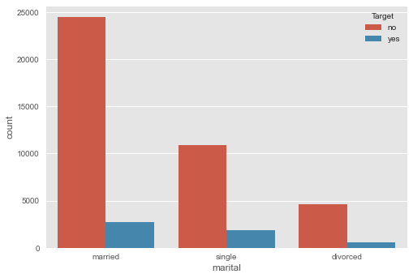

```python
sns.countplot(x="marital", data=dfterm, hue="Target")
```

#### From absolute numbers perspective, more married people have subscribed to Term deposit followed by Single and divorced are the least group that has subscribed to the Bank's Term deposit. Also, from absolute numbers perspective married people are also mre likey to not take Term deposit compared to those who are single and divorced are least in saying no to term deposit. Given this, it would seem, that marital ststus and Target may have very less correlation.

#### Education Vs Target

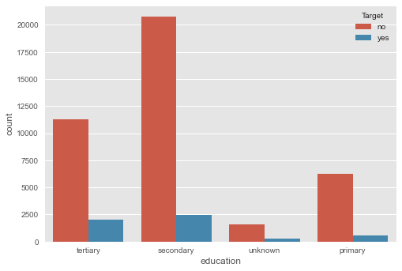

```python
sns.countplot(x="education", data=dfterm, hue="Target")
```

#### From above plot it seems that the percentage / ratio of people accepting the Term deposit is highest followed by the groups with secondary and 'unknown' level of education s tese teo groups have acceptance percetage / ratio that is very close. The group of people with primary level of education is most likey to decline the term deposit i.e. the acceptance percentage / ratio is lowest. While there is a difference in the ratio or percentage of yes to total size of each corresponding group the difference is not too high as it range from around 15.3% to 8.3%. And as this estimation is an approximation based on the plot we can consider very less correlation between the level of education and the possibility of that team accepting the Term deposit offered.

#### Duration Vs Target

[figure not shown]

```python
sns.countplot(x="duration", data=dfterm, hue="Target")
```

#### Poutcome and Target

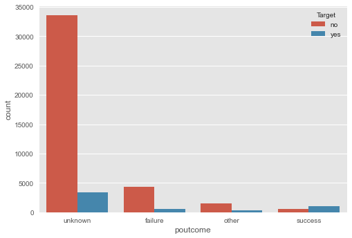

```python
sns.countplot(x="poutcome", data=dfterm, hue="Target")
```

#### Poutcome of 0, 1, 2 and 3 are unknown, failure, other and success. As seen from the plot for the first three outcomes shows high 'no' as the value of Target. But when thw poutome is success then the yes is higher then no as target value. Thus we can say there is a reasonably strong relation between poutcome and target.

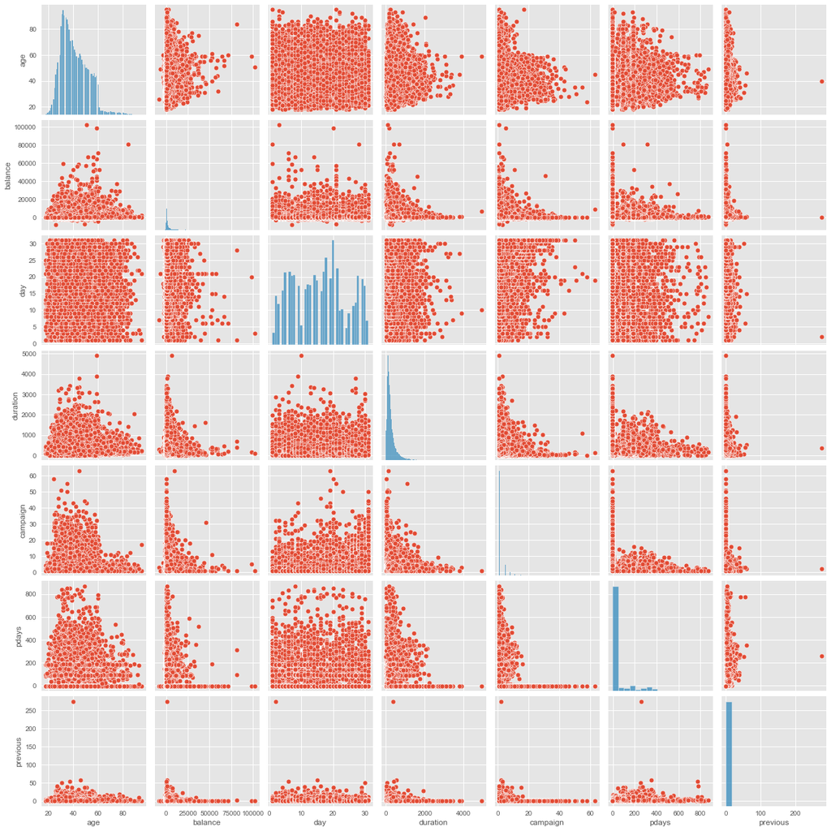

```python
sns.pairplot(dfterm)
```

#### a. 'Balance' is inversly related to duration and campaign and also to a lesser extent is invesly related to pdays. Thus higher the balance lower is the duration i.e. last contact was recent but the number of contacts during this campaign also has been low for such high balance account customers. For such cases the pdays i.e. the numbere of days elapsed since last contact is also low i.e. as reflected by duration customer with high account balance have been recently been cantacted though at a low frequency.

#### b. 'Age' has not corelation with any of the other attributes

#### c. 'Duration' i.e. the last contact duration inseconds is inversly related to balance, campaign and pdays. This higer the balance lesser is the time spent during campaign with the account holding customer. Similarly higher the number of times the customer has been contacted as part of campaign lower is the amount of time spent or duration is less. On the same note lower the pdays higher is the time spent with the client as part of campaign which shows only recently would there have been a stress by management to asking the field staff to spend more and more time with the customers, most likely, selling them with Term deposit scheme.

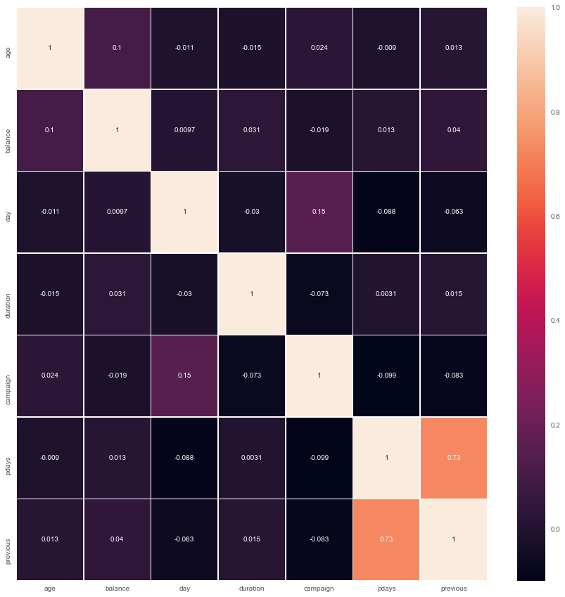

```python
plt.figure(figsize=(15,15))
sns.heatmap(dfterm2.corr(),annot=True,Linewidths=0.5)
plt.show()
```

#### Based on the heatmap with 0.73, there is a high positive co-relation between pdays and previous.Thus higher pdays translates to higer previous i.e. higher the numbwer of days since last contcted higher is the number of times the client was contacted in the previous campaign. Lower the pdays i.e. if the clien has ben conatcted in the last few days o the previous campaign then fewer would have bee the conatcts. This means that during the previous campaign there was higher conatct with the clients but as the days went by the contacts reduced towards the end of the previous campaign.

#### There is a low level positive correlation of 0.15 between campaign and day. Thus lesser the day i.e if the client was contacted recently then campaign may also be less i.e. the number of times the client has been contacted is less. This would indicate slow pace of contacts being done in recent days and thus the management should focus and lead the field team to actively keep contacting the customers.

#### There is a very weak and positive corelation of 0.1 between age and balance indicaring higher the age of the customer higher is the possibility of higher balance in the customer's bank account. The management can ask its tea to focus on such clients as they would have more savings which they can store in term deposites.

## Deliverable -2 (Prepare the data for analytics)

### 1. Ensure the attribute types are correct. If not, take appropriate actions

dfterm3=dfterm

```python
dfterm2['job'] = pd.factorize(dfterm2.job)[0]
dfterm2['marital'] = pd.factorize(dfterm2.job)[0]
dfterm2['education'] = pd.factorize(dfterm2.education)[0]
dfterm2['default'] = pd.factorize(dfterm2.default)[0]
dfterm2['housing'] = pd.factorize(dfterm2.housing)[0]
dfterm2['loan'] = pd.factorize(dfterm2.loan)[0]
dfterm2['contact'] = pd.factorize(dfterm2.contact)[0]
dfterm2['month'] = pd.factorize(dfterm2.month)[0]
dfterm2['poutcome'] = pd.factorize(dfterm2.poutcome)[0]
dfterm2['Target'] = pd.factorize(dfterm2.Target)[0]
```

##### Correcting the data types for various attributes to enable logistic regression and decision tree analysis

### 2. Get the data model ready.

We will use the sklearn library to build the model

```python
dfterm2.info()
```

```
<class 'pandas.core.frame.DataFrame'>
Int64Index: 41320 entries, 0 to 45209
Data columns (total 17 columns):
 #   Column     Non-Null Count  Dtype
---  ------     --------------  -----
 0   age        41320 non-null  int64
 1   job        41320 non-null  int64
 2   marital    41320 non-null  int64
 3   education  41320 non-null  int64
 4   default    41320 non-null  int64
 5   balance    41320 non-null  int64
 6   housing    41320 non-null  int64
 7   loan       41320 non-null  int64
 8   contact    41320 non-null  int64
 9   day        41320 non-null  int64
 10  month      41320 non-null  int64
 11  duration   41320 non-null  int64
 12  campaign   41320 non-null  int64
 13  pdays      41320 non-null  int64
 14  previous   41320 non-null  int64
 15  poutcome   41320 non-null  int64
 16  Target     41320 non-null  int64
dtypes: int64(17)
memory usage: 5.7 MB
```

```python
## Define X and Y variables
X = dfterm2.drop('Target', axis=1)
Y = dfterm2[['Target']]
```

### 3. Transform the data i.e. scale / normalize if required

```python
#Convert categorical vriables to dummy variables
X = pd.get_dummies(X, drop_first=True)
```

### 4. Create the training set and test set in ratio of 70:30

#### Split into training and test set

```python
from sklearn.model_selection import train_test_split

X_train, X_test, y_train, y_test = train_test_split(X, Y, test_size=0.30,random_state=7)
```

```python
print(X_train.shape)
print(y_train.shape)
print(X_test.shape)
print(y_test.shape)
```

```
(28924, 16)
(28924, 1)
(12396, 16)
(12396, 1)
```

Based on the data above we can confirm that the data fame has been correctly divided into Train and Test Datasets.

## Deliverable -3 (Create the ensmble model)

### 1. First create models using Logistic Regression and Decision Tree algorithm.

### Logistic Regression:

```python
from sklearn.metrics import confusion_matrix, recall_score, precision_score, f1_score, roc_auc_score,accuracy_score
from sklearn.linear_model import LogisticRegression

logreg = LogisticRegression()
logreg.fit(X_train, y_train)                    # fit the model on train data
```

```
LogisticRegression(C=1.0, class_weight=None, dual=False, fit_intercept=True,
                   intercept_scaling=1, l1_ratio=None, max_iter=100,
                   multi_class='auto', n_jobs=None, penalty='l2',
                   random_state=None, solver='lbfgs', tol=0.0001, verbose=0,
                   warm_start=False)
```

```python
y_predict = logreg.predict(X_test)              # Predicting the target variable on test data
```

```python
# Observe the predicted and observed classes in a dataframe.

z = X_test.copy()
z['Observed Loan Status'] = y_test
z['Predicted Loan Status'] = y_predict
z.head()
```

|  | age | job | marital | education | default | balance | housing | loan | contact | day | month | duration | campaign | pdays | previous | poutcome | Observed Loan Status | Predicted Loan Status |
| --- | --- | --- | --- | --- | --- | --- | --- | --- | --- | --- | --- | --- | --- | --- | --- | --- | --- | --- |
| 31716 | 38 | 7 | 7 | 1 | 0 | 167 | 0 | 0 | 1 | 7 | 10 | 255 | 2 | -1 | 0 | 0 | 0 | 0 |
| 42181 | 81 | 5 | 5 | 2 | 0 | 9224 | 1 | 0 | 2 | 9 | 5 | 235 | 2 | -1 | 0 | 0 | 0 | 0 |
| 5124 | 32 | 0 | 0 | 0 | 0 | 1756 | 0 | 0 | 0 | 21 | 0 | 206 | 3 | -1 | 0 | 0 | 0 | 0 |
| 7834 | 27 | 1 | 1 | 1 | 0 | 430 | 0 | 1 | 0 | 30 | 0 | 78 | 3 | -1 | 0 | 0 | 0 | 0 |
| 6532 | 31 | 0 | 0 | 0 | 0 | 1183 | 0 | 0 | 0 | 27 | 0 | 676 | 6 | -1 | 0 | 0 | 0 | 0 |

```python
## function to get confusion matrix in a proper format
def draw_cm( actual, predicted ):
    cm = confusion_matrix( actual, predicted)
    sns.heatmap(cm, annot=True,  fmt='.2f', xticklabels = [0,1] , yticklabels = [0,1] )
    plt.ylabel('Observed')
    plt.xlabel('Predicted')
    plt.show()
```

```
Trainig accuracy 0.8946203844558153

Testing accuracy 0.8946434333656018

Confusion Matrix
```

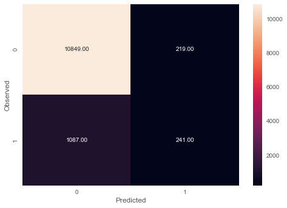

```
None

Recall: 0.18147590361445784

Precision: 0.5239130434782608

F1 Score: 0.2695749440715884

Roc Auc Score: 0.5808445654682336
```

```python
print("Trainig accuracy",logreg.score(X_train,y_train))
print()
print("Testing accuracy",logreg.score(X_test, y_test))
print()
print('Confusion Matrix')
print(draw_cm(y_test,y_predict))
print()
print("Recall:",recall_score(y_test,y_predict))
print()
print("Precision:",precision_score(y_test,y_predict))
print()
print("F1 Score:",f1_score(y_test,y_predict))
print()
print("Roc Auc Score:",roc_auc_score(y_test,y_predict))
```

#### The Logistics Regression model has yielded a low precision and a lower recall. This model would need to be tuned further to improve the performance.

#### The F1 score os 0.27 is also very. Since F1 score is a weighted average of recall and precision and both being low a low F1 sxore is expected indicating a poor performing logistic regression model.

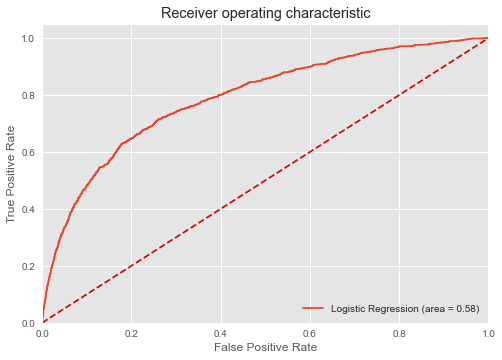

```python
#AUC ROC curve
from sklearn.metrics import roc_auc_score
from sklearn.metrics import roc_curve

logit_roc_auc = roc_auc_score(y_test, logreg.predict(X_test))
fpr, tpr, thresholds = roc_curve(y_test, logreg.predict_proba(X_test)[:,1])
plt.figure()
plt.plot(fpr, tpr, label='Logistic Regression (area = %0.2f)' % logit_roc_auc)
plt.plot([0, 1], [0, 1],'r--')
plt.xlim([0.0, 1.0])
plt.ylim([0.0, 1.05])
plt.xlabel('False Positive Rate')
plt.ylabel('True Positive Rate')
plt.title('Receiver operating characteristic')
plt.legend(loc="lower right")
plt.savefig('Log_ROC')
plt.show()
```

### Create the decision tree model using “entropy” method of finding the split columns and fit it to training data

```python
##### splitting data into training and test set for independent attributes
from sklearn.model_selection import train_test_split

features = [col for col in dfterm2.columns if col != 'Target']

X_train, X_test, y_train, y_test = train_test_split(dfterm2[features], dfterm2['Target'], test_size=.3, random_state=22)
X_train.shape, X_test.shape
```

```
((28924, 16), (12396, 16))
```

```python
# invoking the decision tree classifier function. Using 'entropy' method of finding the split columns. Other option
# could be gini index.

model_entropy = DecisionTreeClassifier(criterion='entropy')
```

```python
model_entropy.fit(X_train, y_train)
```

```
DecisionTreeClassifier(ccp_alpha=0.0, class_weight=None, criterion='entropy',
                       max_depth=None, max_features=None, max_leaf_nodes=None,
                       min_impurity_decrease=0.0, min_impurity_split=None,
                       min_samples_leaf=1, min_samples_split=2,
                       min_weight_fraction_leaf=0.0, presort='deprecated',
                       random_state=None, splitter='best')
```

#### Print the accuracy of the model & print the confusion matrix

```python
print("Train: %.2f" % model_entropy.score(X_train, y_train))  # performance on train data
print("Test: %.2f" % model_entropy.score(X_test, y_test))  # performance on test data
```

```
Train: 1.00
Test: 0.89
```

```python
clf_pruned = DecisionTreeClassifier(criterion = "entropy", max_depth=4)
clf_pruned.fit(X_train, y_train)
```

```
DecisionTreeClassifier(ccp_alpha=0.0, class_weight=None, criterion='entropy',
                       max_depth=4, max_features=None, max_leaf_nodes=None,
                       min_impurity_decrease=0.0, min_impurity_split=None,
                       min_samples_leaf=1, min_samples_split=2,
                       min_weight_fraction_leaf=0.0, presort='deprecated',
                       random_state=None, splitter='best')
```

```python
print("Train: %.2f" % clf_pruned.score(X_train, y_train))  # performance on train data
print("Test: %.2f" % clf_pruned.score(X_test, y_test))  # performance on test data
```

```
Train: 0.91
Test: 0.91
```

#### With a depth of 4 the model has moved from a overfitting model, as Train accuracy was 1 and Test accuracy was 0.89, to a exce llent fitting model as the accuracy for both Train data and Test data is 0.91

#### This proves that a decision tree is an overfitting model and by pruning and reducing the depth of the tree the model can be made better fitting.

### Decision Tree Performance

```python
y_train.value_counts()
```

```
0    25846
1     3078
Name: Target, dtype: int64
```

```python
pip install pydotplus
```

```python
pip install graphviz
```

```python
sudo apt-get install graphviz
```

```python
from sklearn.tree import export_graphviz
from sklearn.externals.six import StringIO
from IPython.display import Image
import pydotplus
import graphviz
```

```python
preds_train = clf_pruned.predict(X_train)
preds_test = clf_pruned.predict(X_test)

acc_DT = accuracy_score(y_test, preds_test)
```

#### Decision tree performance

```python
# Confusion matrix
pd.crosstab(y_test, preds_test, rownames=['Actual'], colnames=['Predicted'])
```

| Predicted Actual | 0 | 1 |
| --- | --- | --- |
| 0 | 10728 | 335 |
| 1 | 806 | 527 |

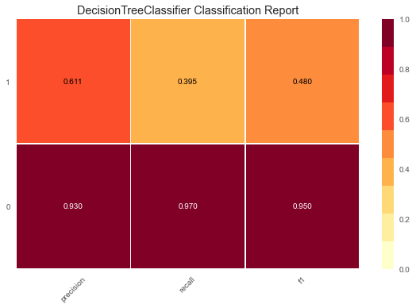

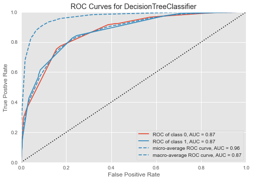

```python
# Visualize model performance with yellowbrick library
viz = ClassificationReport(DecisionTreeClassifier(criterion = "entropy", max_depth=4))
viz.fit(X_train, y_train)
viz.score(X_test, y_test)
viz.show()

roc = ROCAUC(DecisionTreeClassifier(criterion = "entropy", max_depth=4))
roc.fit(X_train, y_train)
roc.score(X_test, y_test)
roc.show()
```

#### Precision is the proportion of correct predictions of that class that are true. So the decision tree is 93% correct in predicting a No to Term deposit subscription.

#### Its precision in correctly predicting a 'Yes' to subscribing the Term deposit is 61.1% which is fairly good but this needs to be improved to ensure customers who have higher probsbility of accepting the subscription are not missed out.

#### Recall is the proportion of the true positives that are identified correctly. This means that this decision tree model is correctly identifying 97% of the class 0s, but only 39.5% of the class 1s. Thus here too the model is strong in identifying which customers would NOT go ahead with subscription but the model does a relatively poorer job in correctily identifying the customers who are very likely to subscribe the Term deposit. As the case in precision thie decision tree model needs to be tuned to increase its recall to help increase the prediction which would help capture a bigger base of Term deposit customers

### Feature Importance

#### Here we will find out of the 16 variables or features in the dataset which features are important in determining the performsnce and thereby the precision and accuracy in predicting the outcome.

```python
## Calculating feature importance

feat_importance = clf_pruned.tree_.compute_feature_importances(normalize=False)


feat_imp_dict = dict(zip(features, clf_pruned.feature_importances_))
feat_imp = pd.DataFrame.from_dict(feat_imp_dict, orient='index')
feat_imp.sort_values(by=0, ascending=False)
```

|  | 0 |
| --- | --- |
| duration | 0.50 |
| poutcome | 0.29 |
| month | 0.12 |
| contact | 0.08 |
| housing | 0.00 |
| pdays | 0.00 |
| age | 0.00 |
| job | 0.00 |
| marital | 0.00 |
| education | 0.00 |
| default | 0.00 |
| balance | 0.00 |
| loan | 0.00 |
| day | 0.00 |
| campaign | 0.00 |
| previous | 0.00 |

#### From the feature importance dataframe we can infer that duration, poutcome,month and contact are the variables that impact the likelihood of subscribing to term deposit.

```python
#Store the accuracy results for each model in a dataframe for final comparison
resultsDf = pd.DataFrame({'Method':['Decision Tree'], 'accuracy': acc_DT})
resultsDf = resultsDf[['Method', 'accuracy']]
resultsDf
```

|  | Method | accuracy |
| --- | --- | --- |
| 0 | Decision Tree | 0.91 |

### Apply Adaboost Ensemble Algorithm for the same data and and note the model performance

```python
from sklearn.ensemble import AdaBoostClassifier
abcl = AdaBoostClassifier(n_estimators = 100, learning_rate=0.1, random_state=22)
abcl = abcl.fit(X_train, y_train)
```

```python
pred_AB =abcl.predict(X_test)
acc_AB = accuracy_score(y_test, pred_AB)
```

```python
tempResultsDf = pd.DataFrame({'Method':['Adaboost'], 'accuracy': [acc_AB]})
resultsDf = pd.concat([resultsDf, tempResultsDf])
resultsDf = resultsDf[['Method', 'accuracy']]
resultsDf
```

|  | Method | accuracy |
| --- | --- | --- |
| 0 | Decision Tree | 0.91 |
| 0 | Adaboost | 0.91 |

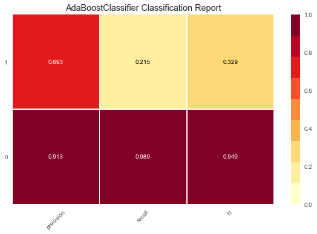

```python
# Visualize model performance with yellowbrick library
viz = ClassificationReport(AdaBoostClassifier(n_estimators= 100, learning_rate=0.1, random_state=22))
viz.fit(X_train, y_train)
viz.score(X_test, y_test)
viz.show()
```

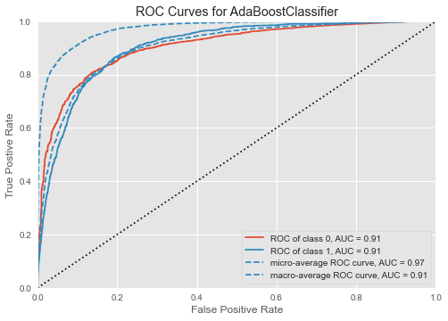

```python
roc = ROCAUC(AdaBoostClassifier(n_estimators= 100, learning_rate=0.1, random_state=22))
roc.fit(X_train, y_train)
roc.score(X_test, y_test)
roc.show()
```

### Apply GradientBoost Classifier Algorithm for the same data and note the model performance

```python
from sklearn.ensemble import GradientBoostingClassifier
gbcl = GradientBoostingClassifier(n_estimators = 50, learning_rate = 0.1, random_state=22)
gbcl = gbcl.fit(X_train, y_train)
```

```python
pred_GB = gbcl.predict(X_test)
acc_GB = accuracy_score(y_test, pred_GB)
```

```python
tempResultsDf = pd.DataFrame({'Method':['Gradient Boost'], 'accuracy': [acc_GB]})
resultsDf = pd.concat([resultsDf, tempResultsDf])
resultsDf = resultsDf[['Method', 'accuracy']]
resultsDf
```

|  | Method | accuracy |
| --- | --- | --- |
| 0 | Decision Tree | 0.91 |
| 0 | Adaboost | 0.91 |
| 0 | Gradient Boost | 0.91 |

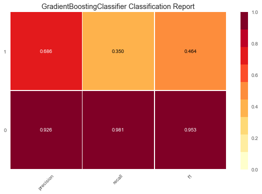

```python
# Visualize model performance with yellowbrick library
viz = ClassificationReport(GradientBoostingClassifier(n_estimators = 50, learning_rate = 0.1, random_state=22))
viz.fit(X_train, y_train)
viz.score(X_test, y_test)
viz.show()
```

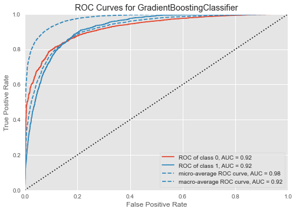

```python
roc = ROCAUC(GradientBoostingClassifier(n_estimators = 50, learning_rate = 0.1, random_state=22))
roc.fit(X_train, y_train)
roc.score(X_test, y_test)
roc.show()
```

### Apply Random Forest for the same data and note the model performance

```python
from sklearn.ensemble import RandomForestClassifier
rfcl = RandomForestClassifier(n_estimators = 50)
rfcl = rfcl.fit(X_train, y_train)
```

```python
pred_RF = rfcl.predict(X_test)
acc_RF = accuracy_score(y_test, pred_RF)
```

```python
tempResultsDf = pd.DataFrame({'Method':['Random Forest'], 'accuracy': [acc_RF]})
resultsDf = pd.concat([resultsDf, tempResultsDf])
resultsDf = resultsDf[['Method', 'accuracy']]
resultsDf
```

|  | Method | accuracy |
| --- | --- | --- |
| 0 | Decision Tree | 0.91 |
| 0 | Adaboost | 0.91 |
| 0 | Gradient Boost | 0.91 |
| 0 | Random Forest | 0.91 |

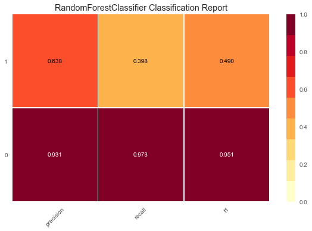

```python
# Visualize model performance with yellowbrick library
viz = ClassificationReport(RandomForestClassifier(n_estimators = 50))
viz.fit(X_train, y_train)
viz.score(X_test, y_test)
viz.show()
```

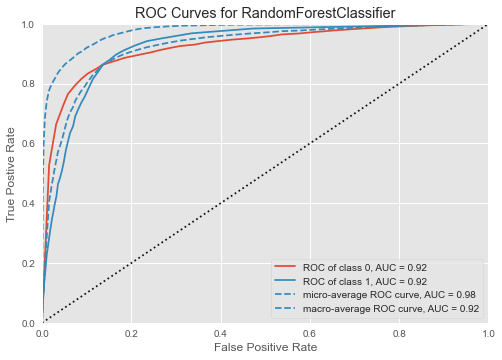

```python
roc = ROCAUC(RandomForestClassifier(n_estimators = 50))
roc.fit(X_train, y_train)
roc.score(X_test, y_test)
roc.show()
```

```python
tempResultsDf
```

|  | Method | accuracy |
| --- | --- | --- |
| 0 | Random Forest | 0.91 |